# Data visualization in R

January 27, 2016

## Graphics in R

## Choices of graphics platforms

You have three central choices for making graphics in R:

- "Base graphics"
- ggplot2
- lattice

## Let there be data….

```r
library(NHANES)
data(NHANES)
str(NHANES)
```

```
## Classes 'tbl_df', 'tbl' and 'data.frame':    10000 obs. of  76 variables:
##  $ ID              : int  51624 51624 51624 51625 51630 51638 51646 51647 51647 51647 ...
##  $ SurveyYr        : Factor w/ 2 levels "2009_10","2011_12": 1 1 1 1 1 1 1 1 1 1 ...
##  $ Gender          : Factor w/ 2 levels "female","male": 2 2 2 2 1 2 2 1 1 1 ...
##  $ Age             : int  34 34 34 4 49 9 8 45 45 45 ...
##  $ AgeDecade       : Factor w/ 8 levels " 0-9"," 10-19",..: 4 4 4 1 5 1 1 5 5 5 ...
##  $ AgeMonths       : int  409 409 409 49 596 115 101 541 541 541 ...
##  $ Race1           : Factor w/ 5 levels "Black","Hispanic",..: 4 4 4 5 4 4 4 4 4 4 ...
##  $ Race3           : Factor w/ 6 levels "Asian","Black",..: NA NA NA NA NA NA NA NA NA NA ...
##  $ Education       : Factor w/ 5 levels "8th Grade","9 - 11th Grade",..: 3 3 3 NA 4 NA NA 5 5 5 ...
##  $ MaritalStatus   : Factor w/ 6 levels "Divorced","LivePartner",..: 3 3 3 NA 2 NA NA 3 3 3 ...
##  $ HHIncome        : Factor w/ 12 levels " 0-4999"," 5000-9999",..: 6 6 6 5 7 11 9 11 11 11 ...
##  $ HHIncomeMid     : int  30000 30000 30000 22500 40000 87500 60000 87500 87500 87500 ...
##  $ Poverty         : num  1.36 1.36 1.36 1.07 1.91 1.84 2.33 5 5 5 ...
##  $ HomeRooms       : int  6 6 6 9 5 6 7 6 6 6 ...
```

[output cut: 62 more lines]

## Graphics in R: Base graphics

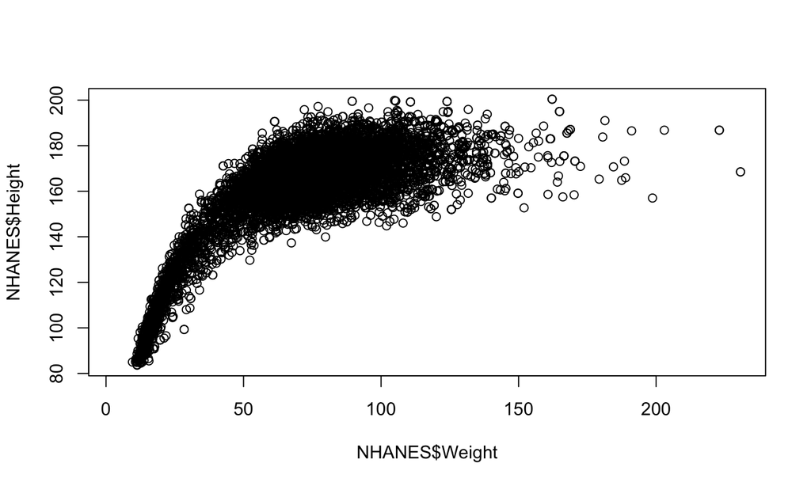

```r
plot(NHANES$Weight, NHANES$Height)
```

## A simple `ggplot2` graphic

```r
library(ggplot2)
qplot(Weight, Height, data=NHANES)
```

[output not shown]

## A simple `lattice` graphic

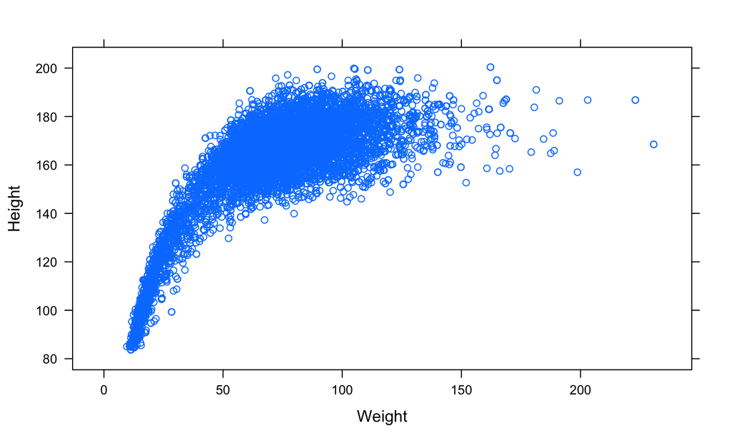

```r
library(lattice)
xyplot(Height ~ Weight, data=NHANES)
```

## The `mosaic` package can translate between them

```r
library(mosaic)
mplot(NHANES)
```

{mplot()} loads a very nice graphical user interface for creating graphics, and spits out the code for ggplot or lattice graphics.

Try it out! Practice saving a graphic from RStudio.

## Why I use `ggplot2`

- ``easy'' to create both simple and complex graphics
- unified syntax
- attractive defaults (except for colors)
- actively developed and improved

## Quick tour of `ggplot2` syntax

```r
## defaults to scatterplot
qplot(Weight, Height, data=NHANES)
```

[output not shown]

## Quick tour of `ggplot2` syntax

```r
## defaults to scatterplot
## same as default
qplot(Weight, Height, data=NHANES, geom="point")
```

[output not shown]

## Quick tour of `ggplot2` syntax

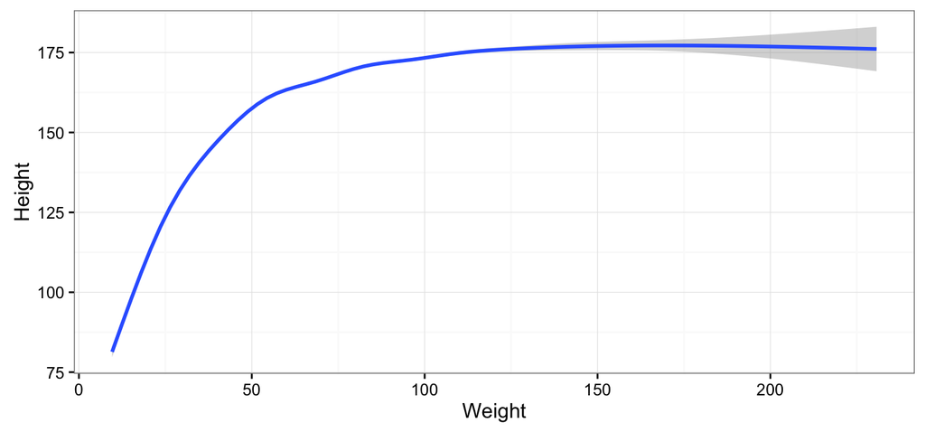

```r
qplot(Weight, Height, data=NHANES, geom="smooth")
```

## Quick tour of `ggplot2` syntax

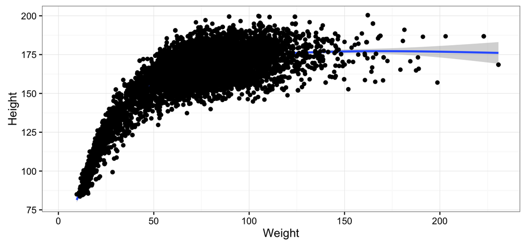

```r
qplot(Weight, Height, data=NHANES,
      geom=c("smooth", "point"))
```

## Quick tour of `ggplot2` syntax

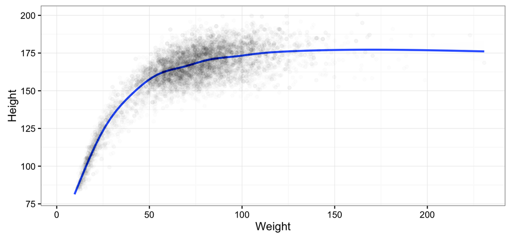

```r
qplot(Weight, Height, data=NHANES,
      geom=c("smooth", "point"), alpha=I(.01))
```

## `ggplot2` building blocks

The grammar …

- geom
- aesthetics (`aes`)
- scales
- facets
- data
- … and more here: http://docs.ggplot2.org/current/

## What is a "geom"?

From http://ggplot2.org/resources/2007-vanderbilt.pdf:

- Geoms define the basic ``shape'' of the elements on the plot
- Basics: point, line, bar, text, hline, vline
- Statistics: histogram, smooth, density
- Others: boxplot, pointrange, linerange, ribbon

For more info check out the documentation: http://docs.ggplot2.org/current/

## What are "aesthetics"?

Aesthetics define a mapping between data and the display.

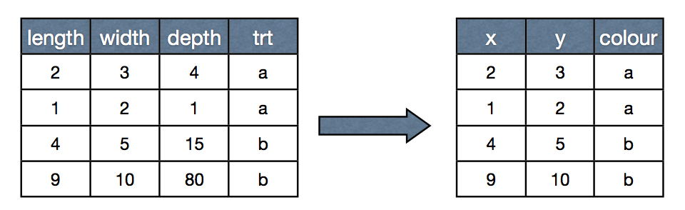

## Thinking about aesthetics

Each geom has a different set of aesthetics.

What aesthetics might we need for {geom_point}?

## Aesthetics for geom_point

{geom_point} understands the following aesthetics

- x (required)
- y (required)
- alpha
- color
- fill
- shape
- size

## Aesthetics for geom_line

What aesthetics might we need for {geom_line}?

## Aesthetics for geom_line

{geom_line} understands the following aesthetics

- x (required)
- y (required)
- alpha
- color
- linetype
- size

## A more involved example

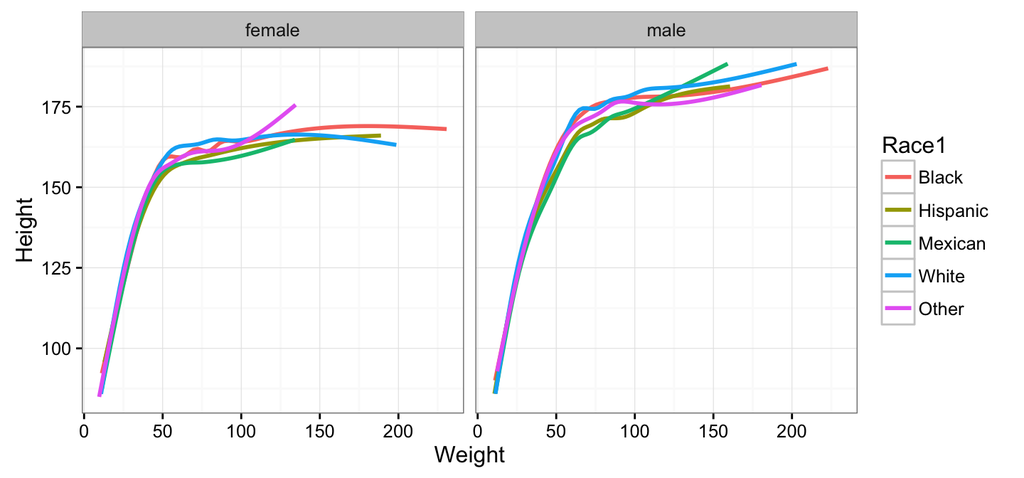

```r
qplot(Weight, Height, data=NHANES,
      geom="smooth", se=FALSE,
      color=Race1,
      facets=.~Gender)
```

## qplot() vs ggplot

```r
qplot(Weight, Height, data=NHANES,
      geom="smooth", se=FALSE,
      color=Race1,
      facets=.~Gender)
```

```r
ggplot(NHANES) +
        geom_smooth(aes(x=Weight, y=Height, color=Race1), se=FALSE) +
        geom_point(aes(x=Weight, y=Height, color=Race1), alpha=I(.01)) +
        facet_grid(.~Gender)
```

## Try it yourself!

## Experiment with mplot - VERY useful!

```r
library(mosaic)
mplot(NHANES)
```

Work on creating a data visualization with a teammate using the NHANES dataset.

By 3:30pm, you should have posted a final version of your data graphic on Piazza, along with the code you used to create it. A few of them will be chosen and discussed by the whole class.